# MidTermAssignment

```python
import pandas as pd
import numpy as np
import matplotlib.pyplot as plt
import os
import random
import seaborn as sns
from collections import defaultdict
```

```python
train_df = pd.read_csv('train.csv')
```

```python
demographics_df = pd.read_csv('demographics_df.csv')
```

```python
demographics_df.head(5)
```

|  | sequence_id | gesture | sequence_type | subject | sequence_lengths | adult_child | age | sex | handedness | height_cm | shoulder_to_wrist_cm | elbow_to_wrist_cm |
| --- | --- | --- | --- | --- | --- | --- | --- | --- | --- | --- | --- | --- |
| 0 | SEQ_000007 | Cheek - pinch skin | Target | SUBJ_059520 | 56 | 0 | 12 | 1 | 1 | 163.0 | 52 | 24.0 |
| 1 | SEQ_000008 | Forehead - pull hairline | Target | SUBJ_020948 | 67 | 1 | 24 | 1 | 1 | 173.0 | 49 | 26.0 |
| 2 | SEQ_000013 | Cheek - pinch skin | Target | SUBJ_040282 | 52 | 0 | 12 | 1 | 1 | 157.0 | 44 | 26.0 |
| 3 | SEQ_000016 | Write name on leg | Non-Target | SUBJ_052342 | 60 | 0 | 13 | 0 | 1 | 171.0 | 54 | 26.0 |
| 4 | SEQ_000018 | Forehead - pull hairline | Target | SUBJ_032165 | 53 | 0 | 13 | 0 | 1 | 165.0 | 52 | 23.0 |

```python
train_df.head(5)
```

|  | row_id | sequence_type | sequence_id | sequence_counter | subject | orientation | behavior | phase | gesture | acc_x | ... | tof_5_v54 | tof_5_v55 | tof_5_v56 | tof_5_v57 | tof_5_v58 | tof_5_v59 | tof_5_v60 | tof_5_v61 | tof_5_v62 | tof_5_v63 |
| --- | --- | --- | --- | --- | --- | --- | --- | --- | --- | --- | --- | --- | --- | --- | --- | --- | --- | --- | --- | --- | --- |
| 0 | SEQ_000007_000000 | Target | SEQ_000007 | 0 | SUBJ_059520 | Seated Lean Non Dom - FACE DOWN | Relaxes and moves hand to target location | Transition | Cheek - pinch skin | 6.683594 | ... | -1.0 | -1.0 | -1.0 | -1.0 | -1.0 | -1.0 | -1.0 | -1.0 | -1.0 | -1.0 |
| 1 | SEQ_000007_000001 | Target | SEQ_000007 | 1 | SUBJ_059520 | Seated Lean Non Dom - FACE DOWN | Relaxes and moves hand to target location | Transition | Cheek - pinch skin | 6.949219 | ... | -1.0 | -1.0 | -1.0 | -1.0 | -1.0 | -1.0 | -1.0 | -1.0 | -1.0 | -1.0 |
| 2 | SEQ_000007_000002 | Target | SEQ_000007 | 2 | SUBJ_059520 | Seated Lean Non Dom - FACE DOWN | Relaxes and moves hand to target location | Transition | Cheek - pinch skin | 5.722656 | ... | -1.0 | -1.0 | 112.0 | 119.0 | -1.0 | -1.0 | -1.0 | -1.0 | -1.0 | -1.0 |
| 3 | SEQ_000007_000003 | Target | SEQ_000007 | 3 | SUBJ_059520 | Seated Lean Non Dom - FACE DOWN | Relaxes and moves hand to target location | Transition | Cheek - pinch skin | 6.601562 | ... | -1.0 | -1.0 | 101.0 | 111.0 | -1.0 | -1.0 | -1.0 | -1.0 | -1.0 | -1.0 |
| 4 | SEQ_000007_000004 | Target | SEQ_000007 | 4 | SUBJ_059520 | Seated Lean Non Dom - FACE DOWN | Relaxes and moves hand to target location | Transition | Cheek - pinch skin | 5.566406 | ... | -1.0 | -1.0 | 101.0 | 109.0 | 125.0 | -1.0 | -1.0 | -1.0 | -1.0 | -1.0 |

5 rows × 341 columns

Taking a randomized sample of the overall population.

```python
number_of_samples = 1000

sequence_ids = train_df['sequence_id'].unique()

random_indices = random.sample(range(len(sequence_ids)), number_of_samples)

random_sequences = sequence_ids[random_indices]

modified_df = []

for sequence in random_sequences:
    tmp = train_df[train_df['sequence_id'] == sequence]

    modified_df.append(tmp)

modified_df = pd.concat(modified_df)

print(modified_df.describe())
```

```
       sequence_counter         acc_x         acc_y         acc_z  \
count      68680.000000  68680.000000  68680.000000  68680.000000
mean          40.619016      1.583022      1.767554     -0.417437
std           35.448414      5.744218      4.993226      6.140474
min            0.000000    -25.402344    -14.828125    -20.507812
25%           17.000000     -2.933594     -2.113281     -5.417969
50%           34.000000      2.878906      0.726562     -1.546875
75%           52.000000      6.246094      6.730469      5.281250
max          303.000000     24.152344     23.128906     19.996094

              rot_w         rot_x         rot_y         rot_z         thm_1  \
count  68148.000000  68148.000000  68148.000000  68148.000000  68264.000000
mean       0.369347     -0.130739     -0.065087     -0.179552     27.159934
std        0.234429      0.459540      0.542871      0.499184      3.000673
min        0.000000     -0.997131     -0.998047     -0.988831     -0.158731
25%        0.176147     -0.458511     -0.518616     -0.604752     24.846363
50%        0.352905     -0.198151     -0.132812     -0.242554     27.117088
75%        0.517212      0.178543      0.429871      0.245377     29.418128
max        0.998169      0.999023      0.999451      0.996399     38.063519

              thm_2  ...     tof_5_v54     tof_5_v55     tof_5_v56  \
count  68157.000000  ...  65346.000000  65346.000000  65346.000000
mean      27.219724  ...     30.980182     27.368775     44.235317
std        2.953891  ...     59.562545     55.397299     67.542988
min       22.135252  ...     -1.000000     -1.000000     -1.000000
25%       24.597441  ...     -1.000000     -1.000000     -1.000000
50%       26.527359  ...     -1.000000     -1.000000     -1.000000
75%       29.763084  ...     41.000000     31.000000     77.000000
max       37.578339  ...    249.000000    249.000000    249.000000

          tof_5_v57     tof_5_v58     tof_5_v59     tof_5_v60     tof_5_v61  \
count  65346.000000  65346.000000  65346.000000  65346.000000  65346.000000
mean      42.921969     40.925917     38.831635     37.123695     33.837480
std       67.405283     67.208915     65.805095     64.840938     62.355052
min       -1.000000     -1.000000     -1.000000     -1.000000     -1.000000
25%       -1.000000     -1.000000     -1.000000     -1.000000     -1.000000
50%       -1.000000     -1.000000     -1.000000     -1.000000     -1.000000
75%       75.000000     67.000000     61.000000     57.000000     47.000000
max      249.000000    249.000000    249.000000    249.000000    249.000000

          tof_5_v62     tof_5_v63
count  65346.000000  65346.000000
mean      30.184495     28.276650
std       58.291222     56.042881
min       -1.000000     -1.000000
25%       -1.000000     -1.000000
50%       -1.000000     -1.000000
75%       39.000000     35.000000
max      249.000000    249.000000

[8 rows x 333 columns]
```

## Cleaning

The first issue about the dataset that needs correction is the format of how the sequence counts of an individual sequence_id are stored in the dataset. Each sequence is stored vertically and the sequence counts for each sequence_id are not necessarily the same.

The difference in sequence counter lengths is due to the difference in times in how long each gesture might take to complete. The different sequence counter lengths require standardization as part of the process of cleaning the dataset. (I wonder if it is feature engineering or data cleaning. It has to be complete before any other data cleaning or feature engineering is complete).

```python
modified_df['sequence_counter'].describe()
```

```
count    68680.000000
mean        40.619016
std         35.448414
min          0.000000
25%         17.000000
50%         34.000000
75%         52.000000
max        303.000000
Name: sequence_counter, dtype: float64
```

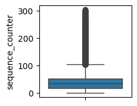

```python
fig = plt.figure(figsize=(2,2))

boxplot_1 = sns.boxplot(data=modified_df['sequence_counter'])

plt.show()
```

Either value 50% or 75% would probably be acceptable in terms of standardization. Given experience with the dataset, I settled on 100 counts.

(**cleaning**) There's also an opportunity to remove some outliers from the dataset.

```python
number_of_timesteps = int(modified_df['sequence_counter'].describe()['75%'])
print(number_of_timesteps)
```

```
52
```

```python
def interpolate_raw(df, n_f=number_of_timesteps):
    # The original function expects a single Series, so we'll adjust it.
    # The interpolation logic will be applied to each row (axis=1).
    s_o_local = df.dropna()
    n_o = s_o_local.shape[0]
    print(df)
    # Guard against empty or single-point series after dropna
    if n_o < 2:
        return np.full(n_f, np.nan)

    t_o = np.linspace(0, n_o, n_o)
    t_f = np.linspace(0, n_o, n_f)

    s_f = np.interp(t_f, t_o, s_o_local.values)
    print(s_f)
    return s_f
```

(**cleaning**) Only the IMU data is used from the dataset. For the purposes of the assignment, a limited dataset should suffice.

```python
column_names = ['sequence_type','sequence_id','subject','gesture']

feature_names = ['columns','acc_x','acc_y','acc_z','rot_x','rot_y','rot_z','rot_w']
```

```python
features_raw = defaultdict(list)

features = defaultdict(list)

for feature in feature_names:
    for name, group in modified_df.groupby('sequence_id'):
        if feature == 'columns':
            tmp = pd.DataFrame(data=group[column_names], columns=column_names)

            tmp.index = [name]*tmp.shape[0]

            features[feature].append(tmp.iloc[0])

            features_raw[feature].append(tmp.iloc[0])

        else:
            tmp = pd.DataFrame(group[feature]).reset_index(drop=True).T

            tmp.index = [name]

            t_f = np.linspace(0, 99, 100)

            t_o = np.linspace(0, 99, tmp.shape[1])

            interpolated_df = pd.DataFrame(np.interp(t_f, t_o, tmp.values[0])).T

            interpolated_df.index = [name]

            features[feature].append(interpolated_df)

            features_raw[feature].append(tmp)

    features[feature] = pd.concat(features[feature])

    features_raw[feature] = pd.concat(features_raw[feature])
```

The above needs a bit of explanation. The value of 100 was used to interpolate each sequence_id into a standardized dataset. Also, each IMU-based feature is appended to a dictionary. The variables features_raw and features are before and after data cleaning.

```python
features['acc_x']
```

|  | 0 | 1 | 2 | 3 | 4 | 5 | 6 | 7 | 8 | 9 | ... | 90 | 91 | 92 | 93 | 94 | 95 | 96 | 97 | 98 | 99 |
| --- | --- | --- | --- | --- | --- | --- | --- | --- | --- | --- | --- | --- | --- | --- | --- | --- | --- | --- | --- | --- | --- |
| SEQ_000008 | 2.765625 | 2.662524 | 2.640901 | 2.672822 | 2.257773 | 2.283539 | 2.585582 | 2.276278 | 2.156250 | 2.145597 | ... | 3.200994 | 3.464252 | 3.495660 | 3.001302 | 3.948666 | 4.252880 | 3.528527 | 3.619831 | 3.092803 | 1.847656 |
| SEQ_000079 | 4.968750 | 4.968750 | 4.865885 | 4.660156 | 4.915365 | 5.055990 | 5.082031 | 5.261719 | 5.300781 | 5.199219 | ... | 0.601562 | 0.421875 | 0.243490 | 0.066406 | -0.496094 | -0.828125 | -0.929688 | -0.906250 | -1.072917 | -1.429688 |
| SEQ_000092 | -10.792969 | -7.551570 | -4.236979 | -0.441406 | 3.543640 | 8.056503 | 10.073627 | 8.287721 | 7.348090 | 7.164062 | ... | -8.861861 | -8.719658 | -8.857599 | -9.309304 | -9.624645 | -9.850497 | -9.471591 | -8.875592 | -9.136285 | -9.527344 |
| SEQ_000297 | 0.687500 | -3.181226 | -7.049953 | -6.572088 | -6.003670 | -5.652225 | -5.310014 | -5.966067 | -6.687224 | -6.101562 | ... | 1.189986 | -0.791390 | -0.963463 | -1.100616 | -0.702336 | -0.329545 | -0.555753 | -0.749487 | 0.615491 | 1.980469 |
| SEQ_000360 | 4.753906 | 4.718000 | 4.842566 | 4.955966 | 4.957939 | 4.945312 | 4.965436 | 5.133681 | 6.789220 | 8.270952 | ... | 8.507812 | 5.437105 | 1.742661 | -0.306581 | -0.808278 | -0.812224 | -0.991832 | -0.739702 | 2.242266 | 7.664062 |
| ... | ... | ... | ... | ... | ... | ... | ... | ... | ... | ... | ... | ... | ... | ... | ... | ... | ... | ... | ... | ... | ... |
| SEQ_065274 | 1.605469 | 2.301886 | 3.013810 | 4.485559 | 5.872080 | 5.213147 | 4.571733 | 4.204782 | 3.918166 | 4.555398 | ... | -6.815341 | -5.828914 | -6.568576 | -7.458333 | -6.910866 | -6.271662 | -5.948745 | -5.639007 | -7.187263 | -8.773438 |
| SEQ_065375 | 8.933594 | 8.022609 | 7.111624 | 5.018111 | 2.845762 | 3.223840 | 3.966264 | 4.105469 | 4.105469 | 4.035866 | ... | 5.604048 | 5.752249 | 5.901870 | 6.113991 | 6.596946 | 6.982363 | 6.685014 | 6.399266 | 6.287524 | 6.175781 |
| SEQ_065413 | 8.605469 | 8.627486 | 8.631747 | 8.609730 | 8.603496 | 8.602075 | 8.604522 | 8.605469 | 8.605035 | 8.578125 | ... | 6.128196 | 5.360046 | 5.511324 | 5.854759 | 6.478575 | 6.533973 | 6.619437 | 7.458531 | 7.239189 | 6.304688 |
| SEQ_065449 | -7.941406 | -7.914260 | -7.907276 | -7.925189 | -7.924519 | -7.895399 | -7.875473 | -7.903093 | -7.869160 | -7.870384 | ... | 3.089844 | 3.055122 | 2.457899 | 2.220762 | 3.328559 | 3.369358 | 3.147135 | 3.186671 | 2.206005 | 3.207031 |
| SEQ_065508 | 9.789062 | 9.789062 | 9.774976 | 9.761719 | 9.761719 | 9.761719 | 9.776634 | 9.780777 | 9.761719 | 9.761719 | ... | -7.059659 | -7.698864 | -6.949574 | -6.969105 | -7.376184 | -7.254853 | -7.502841 | -7.466974 | -7.225852 | -6.906250 |

1000 rows × 100 columns

```python
features_raw['acc_x']
```

|  | 0 | 1 | 2 | 3 | 4 | 5 | 6 | 7 | 8 | 9 | ... | 294 | 295 | 296 | 297 | 298 | 299 | 300 | 301 | 302 | 303 |
| --- | --- | --- | --- | --- | --- | --- | --- | --- | --- | --- | --- | --- | --- | --- | --- | --- | --- | --- | --- | --- | --- |
| SEQ_000008 | 2.765625 | 2.613281 | 2.691406 | 2.078125 | 2.613281 | 2.156250 | 2.156250 | 2.039062 | 2.078125 | 2.117188 | ... | NaN | NaN | NaN | NaN | NaN | NaN | NaN | NaN | NaN | NaN |
| SEQ_000079 | 4.968750 | 4.968750 | 4.660156 | 5.042969 | 5.082031 | 5.351562 | 5.199219 | 5.503906 | 5.390625 | 5.390625 | ... | NaN | NaN | NaN | NaN | NaN | NaN | NaN | NaN | NaN | NaN |
| SEQ_000092 | -10.792969 | -4.738281 | 2.351562 | 10.781250 | 7.445312 | 7.101562 | 5.722656 | 4.843750 | 5.187500 | 4.996094 | ... | NaN | NaN | NaN | NaN | NaN | NaN | NaN | NaN | NaN | NaN |
| SEQ_000297 | 0.687500 | -7.128906 | -5.980469 | -5.289062 | -6.746094 | -5.328125 | -5.441406 | -5.136719 | -5.710938 | -9.886719 | ... | NaN | NaN | NaN | NaN | NaN | NaN | NaN | NaN | NaN | NaN |
| SEQ_000360 | 4.753906 | 4.714844 | 4.867188 | 4.984375 | 4.945312 | 4.945312 | 4.984375 | 5.328125 | 9.460938 | 5.097656 | ... | NaN | NaN | NaN | NaN | NaN | NaN | NaN | NaN | NaN | NaN |
| ... | ... | ... | ... | ... | ... | ... | ... | ... | ... | ... | ... | ... | ... | ... | ... | ... | ... | ... | ... | ... | ... |
| SEQ_065274 | 1.605469 | 2.984375 | 5.898438 | 4.593750 | 3.867188 | 5.128906 | 4.824219 | 4.785156 | 6.472656 | 4.097656 | ... | NaN | NaN | NaN | NaN | NaN | NaN | NaN | NaN | NaN | NaN |
| SEQ_065375 | 8.933594 | 7.054688 | 2.574219 | 4.105469 | 4.105469 | 3.914062 | 3.953125 | 3.992188 | 4.070312 | 3.953125 | ... | NaN | NaN | NaN | NaN | NaN | NaN | NaN | NaN | NaN | NaN |
| SEQ_065413 | 8.605469 | 8.640625 | 8.605469 | 8.601562 | 8.605469 | 8.605469 | 8.562500 | 8.562500 | 8.562500 | 8.605469 | ... | NaN | NaN | NaN | NaN | NaN | NaN | NaN | NaN | NaN | NaN |
| SEQ_065449 | -7.941406 | -7.910156 | -7.906250 | -7.937500 | -7.910156 | -7.867188 | -7.906250 | -7.867188 | -7.871094 | -7.910156 | ... | NaN | NaN | NaN | NaN | NaN | NaN | NaN | NaN | NaN | NaN |
| SEQ_065508 | 9.789062 | 9.789062 | 9.761719 | 9.761719 | 9.761719 | 9.789062 | 9.761719 | 9.761719 | 9.761719 | 9.761719 | ... | NaN | NaN | NaN | NaN | NaN | NaN | NaN | NaN | NaN | NaN |

1000 rows × 304 columns

```python
print(f"Number of Null values per sequence before cleaning (acc_x before cleaning).\n")

print(features_raw['acc_x'].isnull()[features_raw['acc_x'].isnull()==True].count(axis=1))
```

```
Number of Null values per sequence before cleaning (acc_x before cleaning).

SEQ_000008    236
SEQ_000079    237
SEQ_000092    250
SEQ_000297    254
SEQ_000360    212
             ...
SEQ_065274    253
SEQ_065375    255
SEQ_065413    241
SEQ_065449    217
SEQ_065508    228
Length: 1000, dtype: int64
```

```python
print(f"Number of Null values per sequence before cleaning (all features before cleaning).\n")

for feature in feature_names:
    print(f"\n{feature}\n{features_raw[feature].isnull()[features_raw[feature].isnull()==True].T.count()}")
```

```
Number of Null values per sequence before cleaning (all features before cleaning).


columns
0

acc_x
SEQ_000008    236
SEQ_000079    237
SEQ_000092    250
SEQ_000297    254
SEQ_000360    212
             ...
SEQ_065274    253
SEQ_065375    255
SEQ_065413    241
SEQ_065449    217
SEQ_065508    228
Length: 1000, dtype: int64

acc_y
SEQ_000008    236
SEQ_000079    237
SEQ_000092    250
SEQ_000297    254
SEQ_000360    212
             ...
SEQ_065274    253
SEQ_065375    255
SEQ_065413    241
SEQ_065449    217
SEQ_065508    228
Length: 1000, dtype: int64

acc_z
SEQ_000008    236
SEQ_000079    237
SEQ_000092    250
SEQ_000297    254
SEQ_000360    212
```

[output cut: 48 more lines]

```
Length: 1000, dtype: int64

rot_w
SEQ_000008    236
SEQ_000079    237
SEQ_000092    250
SEQ_000297    254
SEQ_000360    212
             ...
SEQ_065274    253
SEQ_065375    255
SEQ_065413    241
SEQ_065449    217
SEQ_065508    228
Length: 1000, dtype: int64
```

(**cleaning**) The datasets before cleaning contain Null values. The process of interpolation extends or retracts all sequence datasets to 100 counts. This is the preferred method over bfill or ffill due to retaining the same curve shape.

```python
print(f"Number of Null values per sequence before cleaning (acc_x after cleaning).\n")

print(features['acc_x'].isnull()[features['acc_x'].isnull()==True].count(axis=1))
```

```
Number of Null values per sequence before cleaning (acc_x after cleaning).

SEQ_000008    0
SEQ_000079    0
SEQ_000092    0
SEQ_000297    0
SEQ_000360    0
             ..
SEQ_065274    0
SEQ_065375    0
SEQ_065413    0
SEQ_065449    0
SEQ_065508    0
Length: 1000, dtype: int64
```

```python
print(f"Number of Null values per sequence before cleaning (all features after).\n")

for feature in feature_names:
    print(f"\n{feature}\n{features[feature].isnull()[features[feature].isnull()==True].T.count()}")
```

```
Number of Null values per sequence before cleaning (all features after).


columns
0

acc_x
SEQ_000008    0
SEQ_000079    0
SEQ_000092    0
SEQ_000297    0
SEQ_000360    0
             ..
SEQ_065274    0
SEQ_065375    0
SEQ_065413    0
SEQ_065449    0
SEQ_065508    0
Length: 1000, dtype: int64

acc_y
SEQ_000008    0
SEQ_000079    0
SEQ_000092    0
SEQ_000297    0
SEQ_000360    0
             ..
SEQ_065274    0
SEQ_065375    0
SEQ_065413    0
SEQ_065449    0
SEQ_065508    0
Length: 1000, dtype: int64

acc_z
SEQ_000008    0
SEQ_000079    0
SEQ_000092    0
SEQ_000297    0
SEQ_000360    0
```

[output cut: 48 more lines]

```
Length: 1000, dtype: int64

rot_w
SEQ_000008    0
SEQ_000079    0
SEQ_000092    0
SEQ_000297    0
SEQ_000360    0
             ..
SEQ_065274    0
SEQ_065375    0
SEQ_065413    0
SEQ_065449    0
SEQ_065508    0
Length: 1000, dtype: int64
```

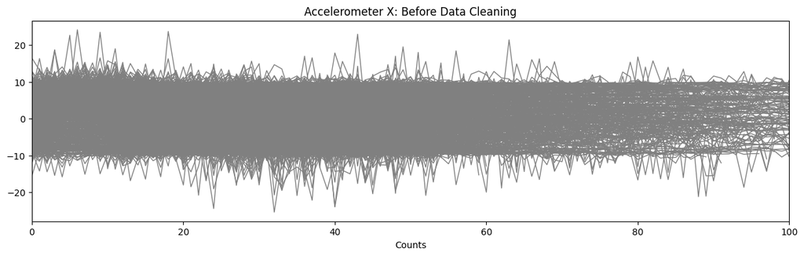

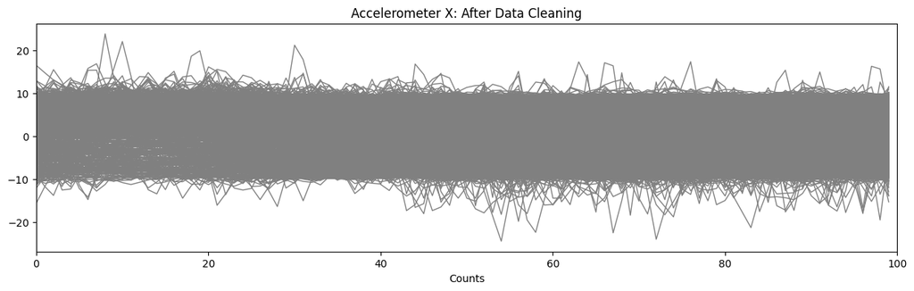

```python
fig = plt.figure(figsize=(15,4))

plt.title("Accelerometer X: Before Data Cleaning")

plt.xlim(0,100)

plt.xlabel("Counts")

for i, row in features_raw['acc_x'].iterrows():
    plt.plot(row, color='gray', linewidth=1)

plt.show()

fig = plt.figure(figsize=(15,4))

plt.xlim(0,100)

plt.xlabel("Counts")

plt.title("Accelerometer X: After Data Cleaning")

for i, row in features['acc_x'].iterrows():
    plt.plot(row, color='gray', linewidth=1)

plt.show()
```

```python
features['acc_x'].describe()
```

|  | 0 | 1 | 2 | 3 | 4 | 5 | 6 | 7 | 8 | 9 | ... | 90 | 91 | 92 | 93 | 94 | 95 | 96 | 97 | 98 | 99 |
| --- | --- | --- | --- | --- | --- | --- | --- | --- | --- | --- | --- | --- | --- | --- | --- | --- | --- | --- | --- | --- | --- |
| count | 1000.000000 | 1000.000000 | 1000.000000 | 1000.000000 | 1000.000000 | 1000.000000 | 1000.000000 | 1000.000000 | 1000.000000 | 1000.000000 | ... | 1000.000000 | 1000.000000 | 1000.000000 | 1000.000000 | 1000.000000 | 1000.000000 | 1000.000000 | 1000.000000 | 1000.000000 | 1000.000000 |
| mean | 2.641520 | 2.830638 | 3.012170 | 3.192022 | 3.403738 | 3.566078 | 3.709788 | 3.734437 | 3.771728 | 3.825191 | ... | 0.280322 | 0.245611 | 0.227907 | 0.224288 | 0.174262 | 0.156676 | 0.074674 | 0.080643 | 0.081302 | 0.100359 |
| std | 5.465497 | 5.239301 | 5.234069 | 5.144395 | 5.099035 | 4.942073 | 4.957989 | 5.000685 | 4.976797 | 4.899178 | ... | 5.811323 | 5.841186 | 5.845332 | 5.828992 | 5.796681 | 5.738660 | 5.772722 | 5.698013 | 5.697949 | 5.826812 |
| min | -15.621094 | -11.711687 | -13.773635 | -12.522846 | -12.284998 | -12.186711 | -14.751302 | -12.775608 | -11.223090 | -10.527344 | ... | -13.844460 | -15.687737 | -16.067472 | -17.410985 | -17.756274 | -12.525331 | -17.977865 | -15.165404 | -19.480114 | -15.289062 |
| 25% | -1.130859 | -0.446664 | -0.056433 | 0.833836 | 1.272767 | 1.545099 | 1.883907 | 2.108842 | 2.092537 | 2.149059 | ... | -4.597390 | -4.733704 | -4.726375 | -4.599313 | -4.625434 | -4.713561 | -4.743164 | -4.706647 | -4.777166 | -4.958984 |
| 50% | 3.929688 | 4.131905 | 4.233902 | 4.540838 | 4.667318 | 4.817472 | 4.871094 | 4.839232 | 4.899029 | 5.020419 | ... | 0.289950 | 0.178938 | 0.286518 | 0.151634 | 0.091639 | -0.025036 | -0.002545 | -0.081124 | -0.088798 | 0.033203 |
| 75% | 6.777344 | 6.753660 | 6.843346 | 6.917259 | 6.999842 | 7.096788 | 7.175337 | 7.268131 | 7.298542 | 7.314719 | ... | 5.354315 | 5.448716 | 5.320243 | 5.440371 | 5.177971 | 5.215584 | 5.216560 | 5.024089 | 5.069277 | 5.196289 |
| max | 16.476562 | 14.744871 | 15.490057 | 12.618608 | 13.601681 | 12.458531 | 15.769531 | 16.854759 | 23.811040 | 15.674361 | ... | 11.390625 | 14.955058 | 11.001657 | 10.513021 | 11.066643 | 11.404514 | 12.027699 | 16.270715 | 15.649976 | 11.519531 |

8 rows × 100 columns

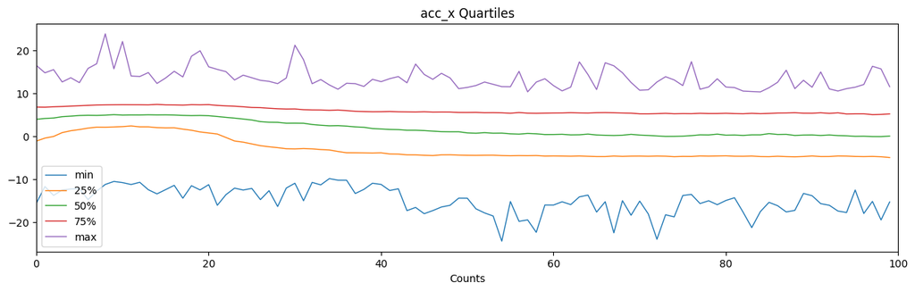

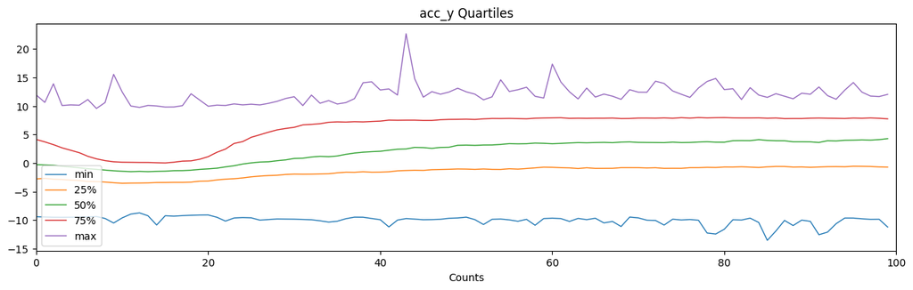

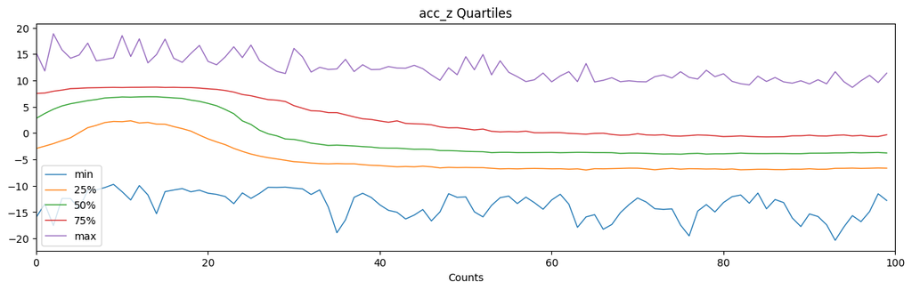

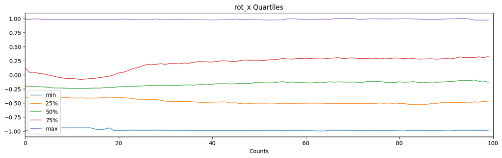

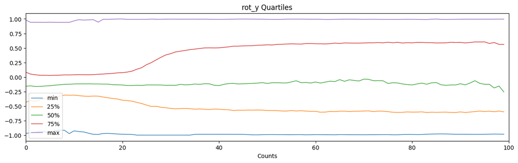

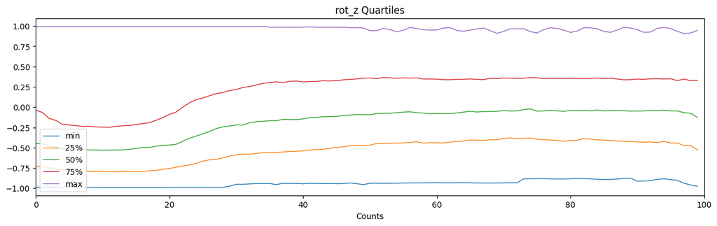

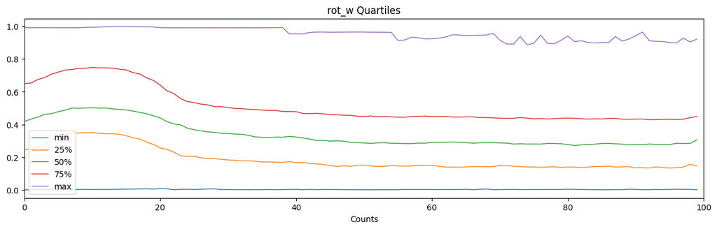

```python
for feature in feature_names:
    if feature == 'columns':
        continue

    fig = plt.figure(figsize=(15,4))

    plt.title(f"{feature} Quartiles")

    plt.xlim(0,100)

    plt.xlabel("Counts")

    plt.plot(features[feature].describe().loc['min'], linewidth=1, label='min')
    plt.plot(features[feature].describe().loc['25%'], linewidth=1, label='25%')
    plt.plot(features[feature].describe().loc['50%'], linewidth=1, label='50%')
    plt.plot(features[feature].describe().loc['75%'], linewidth=1, label='75%')
    plt.plot(features[feature].describe().loc['max'], linewidth=1, label='max')

    plt.legend(loc='lower left')

    plt.show()
```

## Feature Engineering

The following engineered features were selected:  
- IMU sensor derivatives  
- acceleration magnitude  
- rotation angle  
- naive magnitude

```python
for feature in feature_names:
    if feature == 'columns':
        continue

    features[feature+'_1st_deriv'] = features[feature].diff(1, axis=1).fillna(method='bfill', axis=1)
```

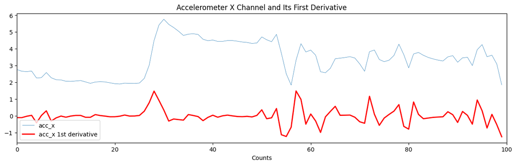

```python
fig = plt.figure(figsize=(15,4))

plt.title(f"Accelerometer X Channel and Its First Derivative")

plt.xlim(0,100)

plt.xlabel("Counts")

plt.plot(features['acc_x'].iloc[0], label='acc_x', linewidth=0.5)

plt.plot(features['acc_x_1st_deriv'].iloc[0], label='acc_x 1st derivative', linewidth=2, color='red')

plt.legend(loc='lower left')

plt.show()
```

(**feature engineering**)The above plot is an example of the first derived feature, the first derivative of the IMU measurements. The business value of this engineered feature, as most engineered features in the space of inertial measurement and control, would be the potentital raising of accuracy, particularly if machine learning is used to stabilize or optimize control algorithms. A specific example could be in better phone location algorithms.

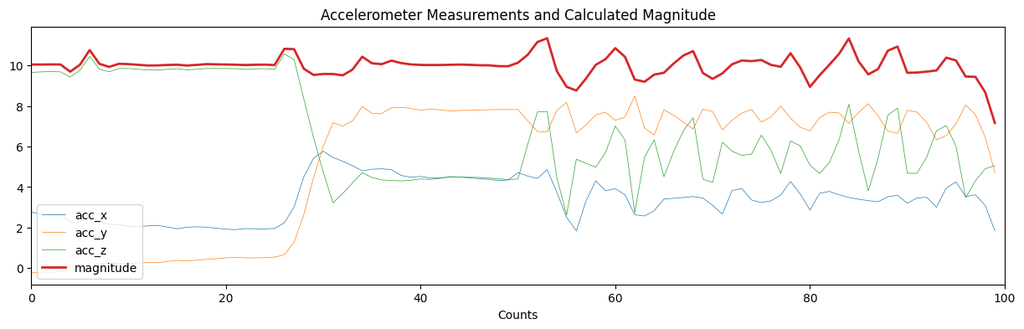

```python
features['accel_magnitude'] = np.sqrt(np.power(features['acc_x'], 2) + np.power(features['acc_y'], 2) + np.power(features['acc_z'], 2))

fig = plt.figure(figsize=(15,4))

plt.title(f"Accelerometer Measurements and Calculated Magnitude")

plt.xlim(0,100)

plt.xlabel("Counts")

plt.plot(features['acc_x'].iloc[0], label='acc_x', linewidth=0.5)
plt.plot(features['acc_y'].iloc[0], label='acc_y', linewidth=0.5)
plt.plot(features['acc_z'].iloc[0], label='acc_z', linewidth=0.5)

plt.plot(features['accel_magnitude'].iloc[0], linewidth=2, label='magnitude')

plt.legend(loc='lower left')

plt.show()
```

(**feature engineering**)The magnitude of the acceleration measurement can be calculated with the following formula:

magnitude = sqrt( x^2 + y^2 + z^2 )

The business use of the acceleration magnitude is an aggregation of all of the acceleration channels, allowing for a measurement that is less complex than having to look at all three at the same time.

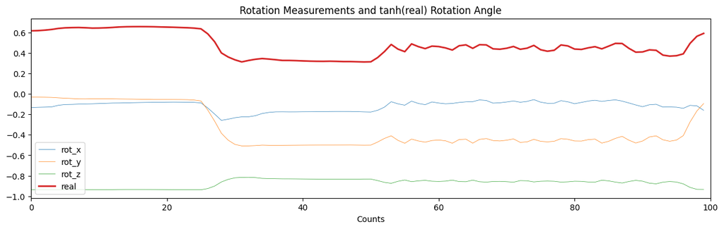

```python
features['real_rotation'] = 2 * np.tanh(features['rot_w'])

fig = plt.figure(figsize=(15,4))

plt.title(f"Rotation Measurements and tanh(real) Rotation Angle")

plt.xlim(0,100)

plt.xlabel("Counts")

plt.plot(features['rot_x'].iloc[0], label='rot_x', linewidth=0.5)
plt.plot(features['rot_y'].iloc[0], label='rot_y', linewidth=0.5)
plt.plot(features['rot_z'].iloc[0], label='rot_z', linewidth=0.5)

plt.plot(features['real_rotation'].iloc[0], linewidth=2, label='real')

plt.legend(loc='lower left')

plt.show()
```

(**feature engineering**)The fourth channel of the rotation measurement is the real portion of the rotation, and a tanh function is applied.

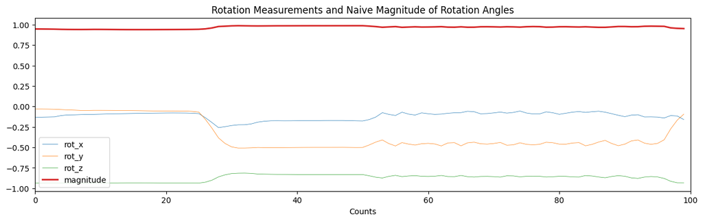

```python
features['rotation_magnitude'] = np.sqrt(np.power(features['rot_x'], 2) + np.power(features['rot_y'], 2) + np.power(features['rot_z'], 2))

fig = plt.figure(figsize=(15,4))

plt.title(f"Rotation Measurements and Naive Magnitude of Rotation Angles")

plt.xlim(0,100)

plt.xlabel("Counts")

plt.plot(features['rot_x'].iloc[0], label='rot_x', linewidth=0.5)
plt.plot(features['rot_y'].iloc[0], label='rot_y', linewidth=0.5)
plt.plot(features['rot_z'].iloc[0], label='rot_z', linewidth=0.5)

plt.plot(features['rotation_magnitude'].iloc[0], linewidth=2, label='magnitude')

plt.legend(loc='lower left')

plt.show()
```

(**feature engineering**)The above is a plot of the naive magnitude of rotation. As the tanh(real) plot above, it is another aggregated feature that can simplify calculations.

```python
features['acc_x_1st_deriv'].describe().mean(axis=1)
```

```
count    1000.000000
mean       -0.023520
std         1.179837
min        -9.178963
25%        -0.209006
50%        -0.001420
75%         0.206122
max         9.018143
dtype: float64
```

```python
features['accel_magnitude'].describe().mean(axis=1)
```

```
count    1000.000000
mean        9.928367
std         0.996496
min         3.860937
25%         9.684617
50%         9.909992
75%        10.138820
max        19.128850
dtype: float64
```

```python
features['real_rotation'].describe().mean(axis=1)
```

```
count    992.000000
mean       0.656080
std        0.359723
min        0.003481
25%        0.369473
50%        0.648481
75%        0.936017
max        1.483556
dtype: float64
```

```python
features['rotation_magnitude'].describe().mean(axis=1)
```

[output not shown]